# Credit_analysis

RUGNepal

October 7, 2018

## Setting up system

```r
#list.files() # prints the files presnt in working directory
```

For Asking help with R

```r
#?function
#help(function or Robject)
```

This is simulated dataset containing information about the customers.The data is about regression problem and we need to analyse this data find some insights and create a machine learning model.

## Loading Library and Data

```r
library(dplyr) #used for data manipulation/wrangling
library(ggplot2) #used for data visualization

# load the data
credit <- read.csv("credit.csv")
```

## Data Manipulation and Analysis

```r
head(credit) # shows first 6 data
```

|  | ID | Income | Limit | Rating | Cards | Age | Education | Gender | Student | Married | Ethnicity | Balance |
| --- | --- | --- | --- | --- | --- | --- | --- | --- | --- | --- | --- | --- |
| 1 | 1 | 14.891 | 3606 | 283 | 2 | 34 | 11 | Male | No | Yes | Caucasian | 333 |
| 2 | 2 | 106.025 | 6645 | 483 | 3 | 82 | 15 | Female | Yes | Yes | Asian | 903 |
| 3 | 3 | 104.593 | 7075 | 514 | 4 | 71 | 11 | Male | No | No | Asian | 580 |
| 4 | 4 | 148.924 | 9504 | 681 | 3 | 36 | 11 | Female | No | No | Asian | 964 |
| 5 | 5 | 55.882 | 4897 | 357 | 2 | 68 | 16 | Male | No | Yes | Caucasian | 331 |
| 6 | 6 | 80.180 | 8047 | 569 | 4 | 77 | 10 | Male | No | No | Caucasian | 1151 |

## Description of dataset

*.ID - Identification

*.Income - Income in $10,000’s

*.Limit - Credit limit

*.Rating - Credit rating

*.Cards - Number of credit cards

*.Age - Age in years

*.Education - Number of years of education

*.Gender - A factor with levels Male and Female

*.Student - A factor with levels No & Yes if an individual was a student

*.Married - A factor with levels No & Yes if an individual was married

*.Ethnicity - A factor with levels African/American/Asian/Caucasian enthnic group

*.Balance - Average credit card balance in $.

We need to analyse and create machine learning model to predict the Bank balance of Customer.

```r
tail(credit) #last 6 data are shown by default
```

|  | ID | Income | Limit | Rating | Cards | Age | Education | Gender | Student | Married | Ethnicity | Balance |
| --- | --- | --- | --- | --- | --- | --- | --- | --- | --- | --- | --- | --- |
| 395 | 395 | 49.794 | 5758 | 410 | 4 | 40 | 8 | Male | No | No | Caucasian | 734 |
| 396 | 396 | 12.096 | 4100 | 307 | 3 | 32 | 13 | Male | No | Yes | Caucasian | 560 |
| 397 | 397 | 13.364 | 3838 | 296 | 5 | 65 | 17 | Male | No | No | African American | 480 |
| 398 | 398 | 57.872 | 4171 | 321 | 5 | 67 | 12 | Female | No | Yes | Caucasian | 138 |
| 399 | 399 | 37.728 | 2525 | 192 | 1 | 44 | 13 | Male | No | Yes | Caucasian | 0 |
| 400 | 400 | 18.701 | 5524 | 415 | 5 | 64 | 7 | Female | No | No | Asian | 966 |

View() shows whole dataset in new tab.

```r
glimpse(credit)
```

```
## Observations: 400
## Variables: 12
## $ ID        <int> 1, 2, 3, 4, 5, 6, 7, 8, 9, 10, 11, 12, 13, 14, 15, 1...
## $ Income    <dbl> 14.891, 106.025, 104.593, 148.924, 55.882, 80.180, 2...
## $ Limit     <int> 3606, 6645, 7075, 9504, 4897, 8047, 3388, 7114, 3300...
## $ Rating    <int> 283, 483, 514, 681, 357, 569, 259, 512, 266, 491, 58...
## $ Cards     <int> 2, 3, 4, 3, 2, 4, 2, 2, 5, 3, 4, 3, 1, 1, 2, 3, 3, 3...
## $ Age       <int> 34, 82, 71, 36, 68, 77, 37, 87, 66, 41, 30, 64, 57, ...
## $ Education <int> 11, 15, 11, 11, 16, 10, 12, 9, 13, 19, 14, 16, 7, 9,...
## $ Gender    <fct>  Male, Female,  Male, Female,  Male,  Male, Female, ...
## $ Student   <fct> No, Yes, No, No, No, No, No, No, No, Yes, No, No, No...
## $ Married   <fct> Yes, Yes, No, No, Yes, No, No, No, No, Yes, Yes, No,...
## $ Ethnicity <fct> Caucasian, Asian, Asian, Asian, Caucasian, Caucasian...
## $ Balance   <int> 333, 903, 580, 964, 331, 1151, 203, 872, 279, 1350, ...
```

```r
#View(credit)
```

```r
dim(credit) #prints dimension of the dataframe (Row, Column)
```

```
## [1] 400  12
```

```r
#rownames(credit) #prints rows names

names(credit) #prints columns header
```

```
##  [1] "ID"        "Income"    "Limit"     "Rating"    "Cards"
##  [6] "Age"       "Education" "Gender"    "Student"   "Married"
## [11] "Ethnicity" "Balance"
```

```r
#colnames(credit) #prints columns header
```

```r
str(credit) #internal structure of the data
```

```
## 'data.frame':    400 obs. of  12 variables:
##  $ ID       : int  1 2 3 4 5 6 7 8 9 10 ...
##  $ Income   : num  14.9 106 104.6 148.9 55.9 ...
##  $ Limit    : int  3606 6645 7075 9504 4897 8047 3388 7114 3300 6819 ...
##  $ Rating   : int  283 483 514 681 357 569 259 512 266 491 ...
##  $ Cards    : int  2 3 4 3 2 4 2 2 5 3 ...
##  $ Age      : int  34 82 71 36 68 77 37 87 66 41 ...
##  $ Education: int  11 15 11 11 16 10 12 9 13 19 ...
##  $ Gender   : Factor w/ 2 levels " Male","Female": 1 2 1 2 1 1 2 1 2 2 ...
##  $ Student  : Factor w/ 2 levels "No","Yes": 1 2 1 1 1 1 1 1 1 2 ...
##  $ Married  : Factor w/ 2 levels "No","Yes": 2 2 1 1 2 1 1 1 1 2 ...
##  $ Ethnicity: Factor w/ 3 levels "African American",..: 3 2 2 2 3 3 1 2 3 1 ...
##  $ Balance  : int  333 903 580 964 331 1151 203 872 279 1350 ...
```

```r
library(knitr)
kable(summary(credit)) #basic statistics
```

|  | ID | Income | Limit | Rating | Cards | Age | Education | Gender | Student | Married | Ethnicity | Balance |
| --- | --- | --- | --- | --- | --- | --- | --- | --- | --- | --- | --- | --- |
|  | Min. : 1.0 | Min. : 10.35 | Min. : 855 | Min. : 93.0 | Min. :1.000 | Min. :23.00 | Min. : 5.00 | Male :193 | No :360 | No :155 | African American: 99 | Min. : 0.00 |
|  | 1st Qu.:100.8 | 1st Qu.: 21.01 | 1st Qu.: 3088 | 1st Qu.:247.2 | 1st Qu.:2.000 | 1st Qu.:41.75 | 1st Qu.:11.00 | Female:207 | Yes: 40 | Yes:245 | Asian :102 | 1st Qu.: 68.75 |
|  | Median :200.5 | Median : 33.12 | Median : 4622 | Median :344.0 | Median :3.000 | Median :56.00 | Median :14.00 | NA | NA | NA | Caucasian :199 | Median : 459.50 |
|  | Mean :200.5 | Mean : 45.22 | Mean : 4736 | Mean :354.9 | Mean :2.958 | Mean :55.67 | Mean :13.45 | NA | NA | NA | NA | Mean : 520.01 |
|  | 3rd Qu.:300.2 | 3rd Qu.: 57.47 | 3rd Qu.: 5873 | 3rd Qu.:437.2 | 3rd Qu.:4.000 | 3rd Qu.:70.00 | 3rd Qu.:16.00 | NA | NA | NA | NA | 3rd Qu.: 863.00 |
|  | Max. :400.0 | Max. :186.63 | Max. :13913 | Max. :982.0 | Max. :9.000 | Max. :98.00 | Max. :20.00 | NA | NA | NA | NA | Max. :1999.00 |

### Explore one variable

In this section we will work on one variable or column data. We will do some basic data maniuplation function from dplyr.

```r
income<-select(credit,Income) #selection of the column
```

```r
length(income)#length of the vector
```

```
## [1] 1
```

```r
dim(income)
```

```
## [1] 400   1
```

```r
head(income)
```

|  | Income |
| --- | --- |
| 1 | 14.891 |
| 2 | 106.025 |
| 3 | 104.593 |
| 4 | 148.924 |
| 5 | 55.882 |
| 6 | 80.180 |

```r
names(income) <-"Dollar"
head(income)
```

|  | Dollar |
| --- | --- |
| 1 | 14.891 |
| 2 | 106.025 |
| 3 | 104.593 |
| 4 | 148.924 |
| 5 | 55.882 |
| 6 | 80.180 |

```r
income<-rename(income,Income = Dollar)
income
```

| Income |
| --- |
| 14.891 |
| 106.025 |
| 104.593 |
| 148.924 |
| 55.882 |
| 80.180 |
| 20.996 |
| 71.408 |
| 15.125 |
| 71.061 |

[output cut: 390 more lines]

```r
min(income) #minimum of the data
```

```
## [1] 10.354
```

```r
max(income) #maximum of the data
```

```
## [1] 186.634
```

###Missing value

```r
head(is.na(income)) #gives logical value
```

```
##      Income
## [1,]  FALSE
## [2,]  FALSE
## [3,]  FALSE
## [4,]  FALSE
## [5,]  FALSE
## [6,]  FALSE
```

```r
sum(is.na(income))
```

```
## [1] 0
```

```r
arrange(income,desc(Income)) #arrange the value in incre and decr order
```

| Income |
| --- |
| 186.634 |
| 182.728 |
| 180.682 |
| 180.379 |
| 163.329 |
| 160.231 |
| 158.889 |
| 152.298 |
| 151.947 |
| 149.316 |

[output cut: 390 more lines]

### Distribution

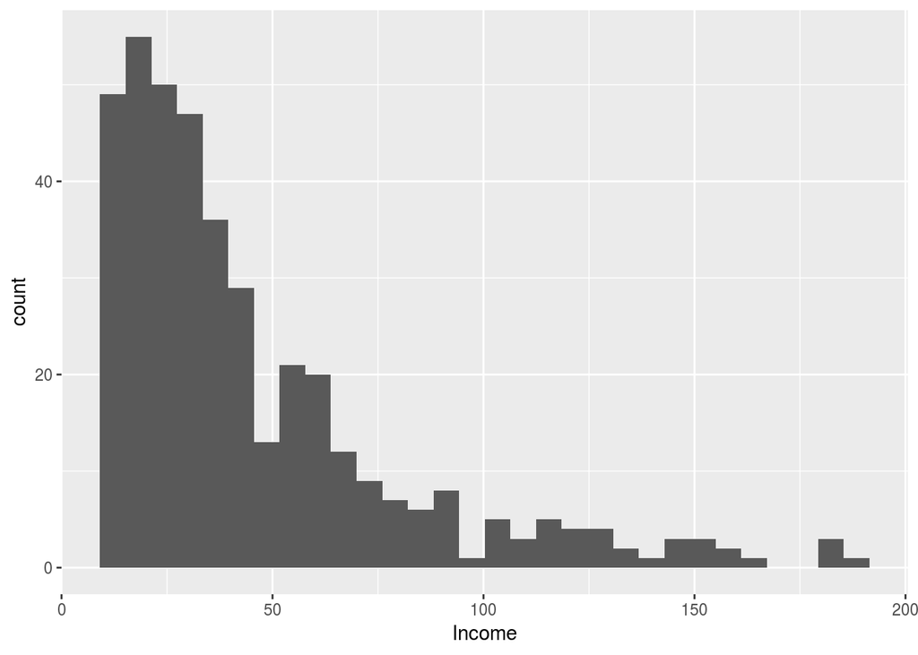

```r
ggplot(income)+geom_histogram(aes(x=Income))
```

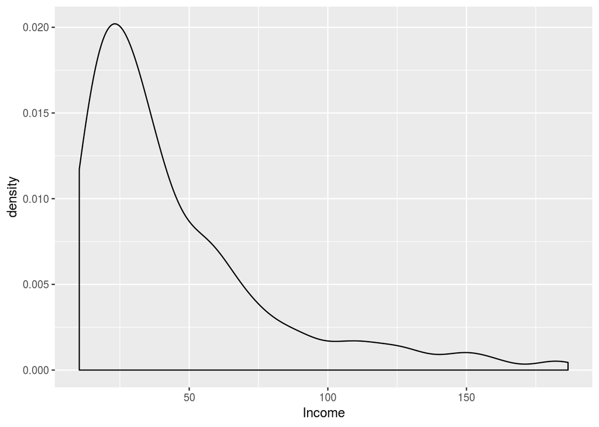

```r
ggplot(income)+geom_density(aes(x=Income))
```

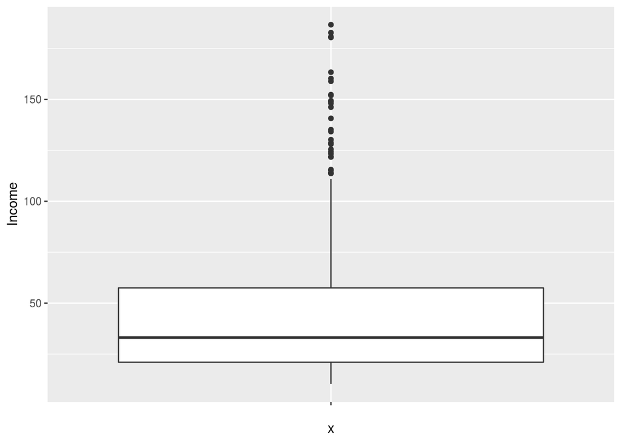

```r
ggplot(income)+geom_boxplot(aes(x="",y=Income))
```

```r
summary(income)
```

```
##      Income
##  Min.   : 10.35
##  1st Qu.: 21.01
##  Median : 33.12
##  Mean   : 45.22
##  3rd Qu.: 57.47
##  Max.   :186.63
```

### Explore multiple variable

In this we will work on multiple variable and analyse the data create some visuals using ggplot2 and base R.

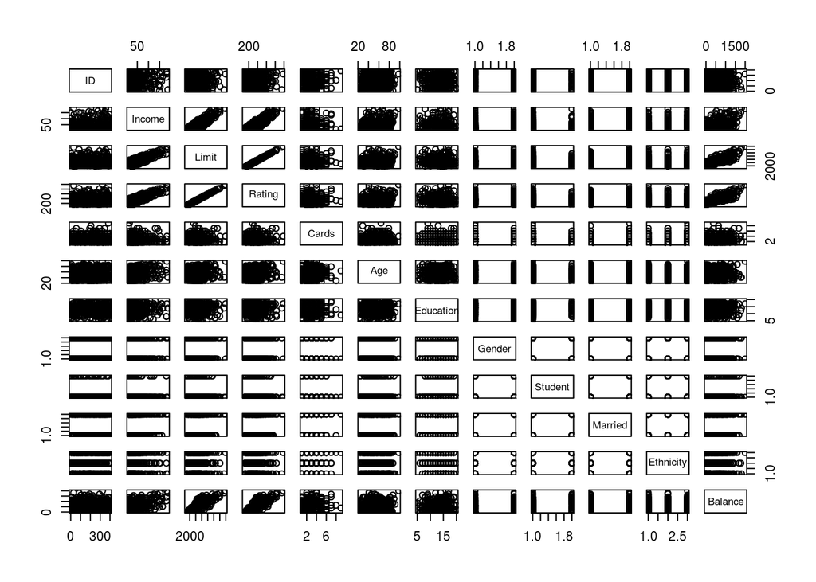

```r
plot(credit)
```

####Distribution of data The density plot shows the distribution of data . Skewness and Kurtosis gives the measure of dispersion of the data.

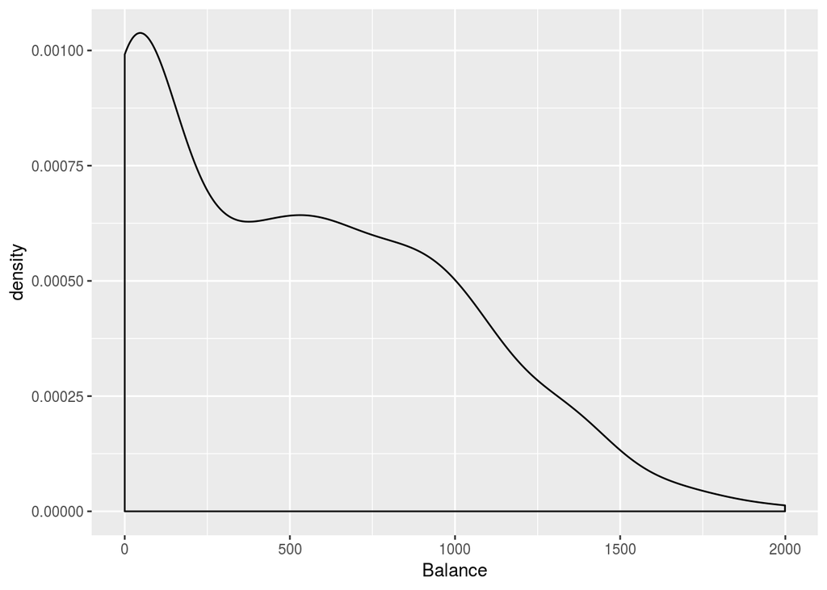

```r
ggplot(credit,aes(x=Balance))+geom_density()
```

```r
library(moments)
skewness(credit$Balance)
```

```
## [1] 0.5824006
```

```r
kurtosis(credit$Balance)
```

```
## [1] 2.463755
```

*.The skewness is measure of a dataset’s symmetry – or lack of symmetry and perfectly symmetrical dataset has 0 skewness.* . Kurtosis is called the degree of peakedness of a distribution but it is actually measure of tail.

####Scatterplot The Scatterplot is used to plot data about two variables and it is also used to show the relation/correlation between two variable.

```r
db1 <- select(credit,Income,Limit)
```

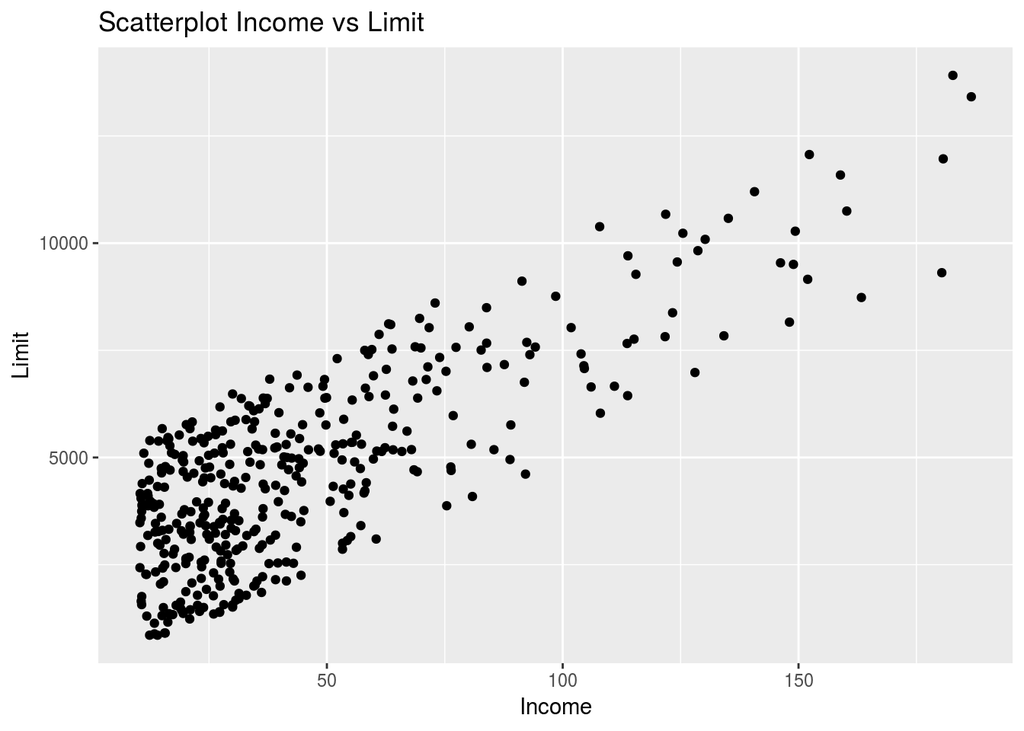

```r
ggplot(db1)+geom_point(aes(x=Income,y=Limit))+ggtitle("Scatterplot Income vs Limit")
```

We can plot more than two variable data by using colors,shape to show third variable data.

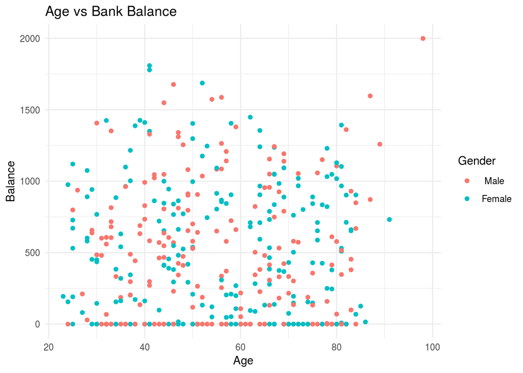

```r
ggplot(data = credit)+geom_point(aes(Age,Balance,color= Gender))+ labs(title="Age vs Bank Balance")+theme_minimal()
```

[figure not shown]

```r
ggplot(data = credit)+geom_point(aes(Income,Balance,color= Married))+ labs(title="Age vs Bank Balance")+theme_minimal()
```

```r
cat("Stats of Age:",summary(credit$Age))
```

```
## Stats of Age: 23 41.75 56 55.6675 70 98
```

```r
cat("\nStats of Balance:",summary(credit$Balance))
```

```
##
## Stats of Balance: 0 68.75 459.5 520.015 863 1999
```

#### Correlation

Corrlation is Degree and type of relationship between any two or more quantities .The value of correlation is between -1 to 1.The 0 shows the no relation between two variables. -1 shows strong negative corelation and +1 shows strong positive correlation.

```r
cls <- sapply(credit,class)
cls
```

```
##        ID    Income     Limit    Rating     Cards       Age Education
## "integer" "numeric" "integer" "integer" "integer" "integer" "integer"
##    Gender   Student   Married Ethnicity   Balance
##  "factor"  "factor"  "factor"  "factor" "integer"
```

```r
credit%>% select(which(cls!="factor"))
```

| ID | Income | Limit | Rating | Cards | Age | Education | Balance |
| --- | --- | --- | --- | --- | --- | --- | --- |
| 1 | 14.891 | 3606 | 283 | 2 | 34 | 11 | 333 |
| 2 | 106.025 | 6645 | 483 | 3 | 82 | 15 | 903 |
| 3 | 104.593 | 7075 | 514 | 4 | 71 | 11 | 580 |
| 4 | 148.924 | 9504 | 681 | 3 | 36 | 11 | 964 |
| 5 | 55.882 | 4897 | 357 | 2 | 68 | 16 | 331 |
| 6 | 80.180 | 8047 | 569 | 4 | 77 | 10 | 1151 |
| 7 | 20.996 | 3388 | 259 | 2 | 37 | 12 | 203 |
| 8 | 71.408 | 7114 | 512 | 2 | 87 | 9 | 872 |
| 9 | 15.125 | 3300 | 266 | 5 | 66 | 13 | 279 |
| 10 | 71.061 | 6819 | 491 | 3 | 41 | 19 | 1350 |

[output cut: 390 more lines]

```r
num_credit<-credit%>% select(which(cls!="factor"))
```

```r
num_credit<- as.data.frame(num_credit)
```

```r
cor(num_credit)
```

```
##                     ID      Income       Limit      Rating       Cards
## ID         1.000000000  0.03720258  0.02417249  0.02198547 -0.03630425
## Income     0.037202580  1.00000000  0.79208834  0.79137763 -0.01827261
## Limit      0.024172487  0.79208834  1.00000000  0.99687974  0.01023133
## Rating     0.021985470  0.79137763  0.99687974  1.00000000  0.05323903
## Cards     -0.036304251 -0.01827261  0.01023133  0.05323903  1.00000000
## Age        0.058603022  0.17533840  0.10088792  0.10316500  0.04294829
## Education -0.001415034 -0.02769198 -0.02354853 -0.03013563 -0.05108422
## Balance    0.006064108  0.46365646  0.86169727  0.86362516  0.08645635
##                   Age    Education      Balance
## ID        0.058603022 -0.001415034  0.006064108
## Income    0.175338403 -0.027691982  0.463656457
## Limit     0.100887922 -0.023548534  0.861697267
## Rating    0.103164996 -0.030135627  0.863625161
## Cards     0.042948288 -0.051084217  0.086456347
## Age       1.000000000  0.003619285  0.001835119
## Education 0.003619285  1.000000000 -0.008061576
## Balance   0.001835119 -0.008061576  1.000000000
```

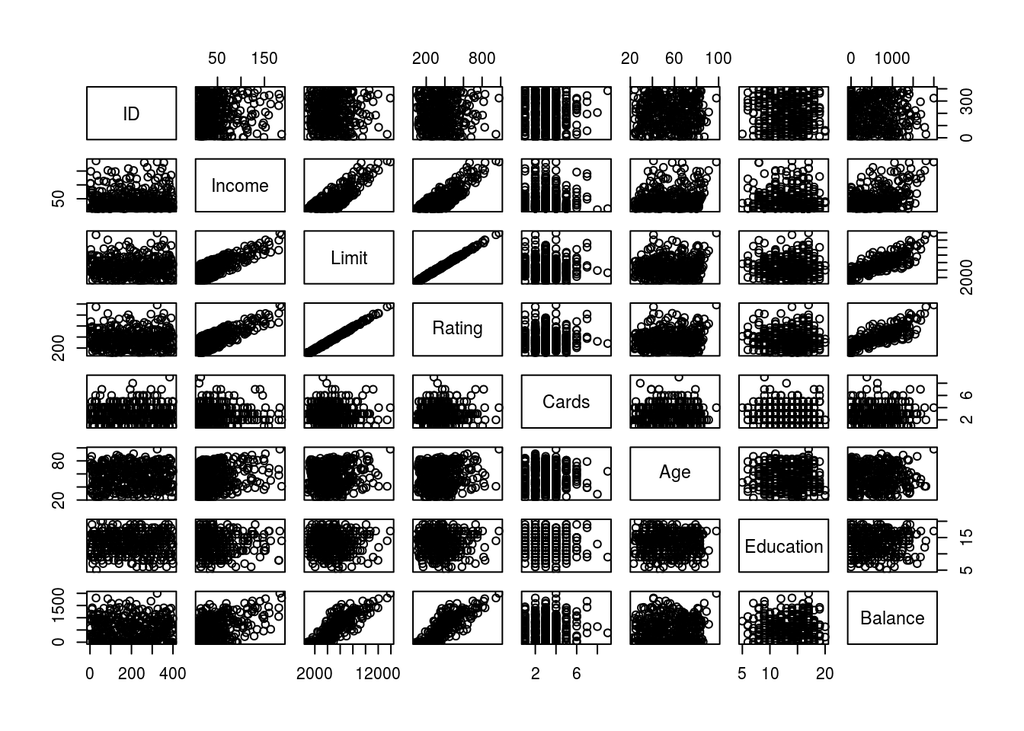

```r
plot(num_credit)
```

In the below plot we use scatterplot to show the relation between two variables. Limit and Rating shows highly postive relation.

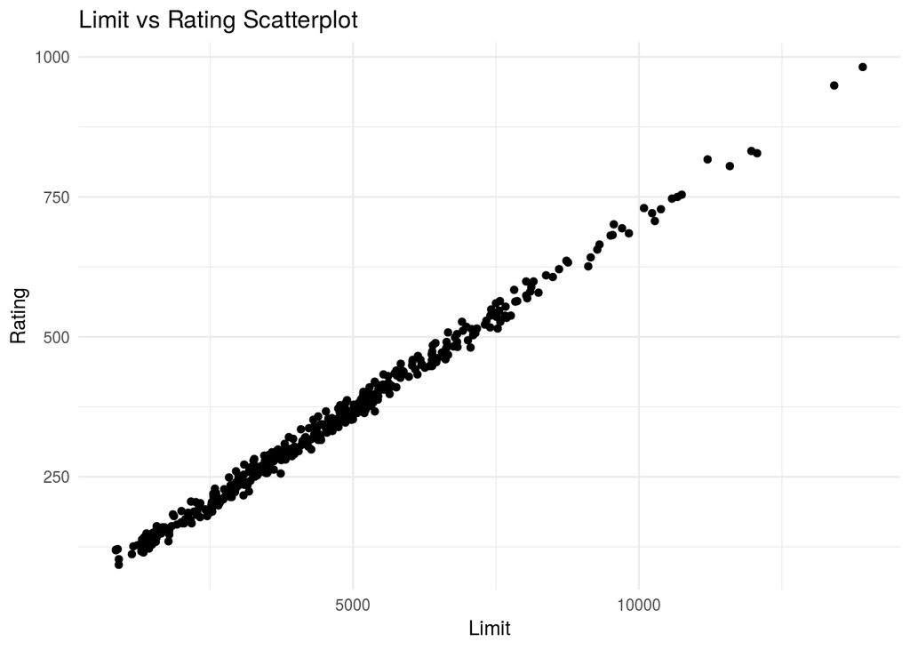

```r
g<- ggplot(num_credit)
g+ geom_point(aes(x=Limit, y= Rating))+labs(title="Limit vs Rating Scatterplot",x="Limit",y="Rating")+theme_minimal()
```

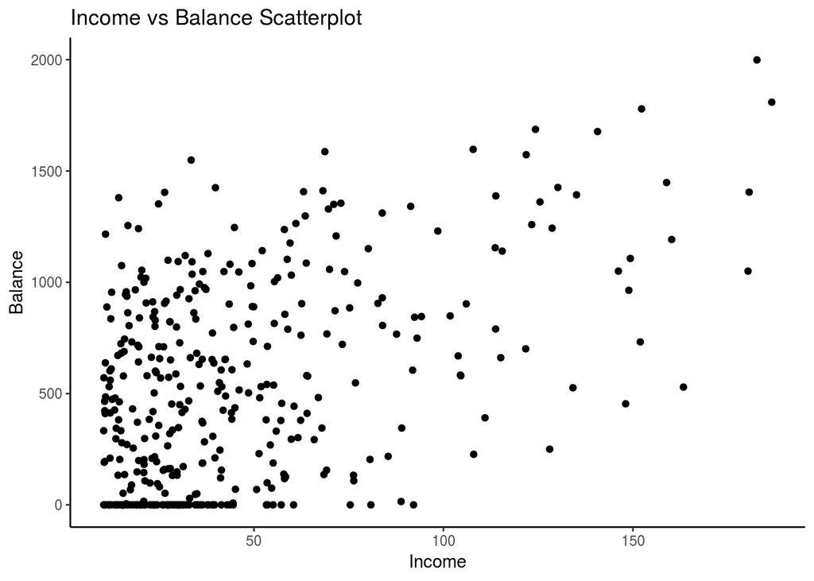

```r
g+ geom_point(aes(x=Income,y=Balance))+labs(title="Income vs Balance Scatterplot")+theme_classic()
```

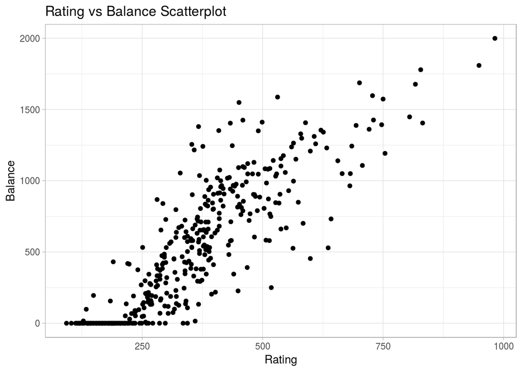

```r
g+ geom_point(aes(x=Rating,y=Balance))+labs(title="Rating vs Balance Scatterplot")+ theme_light()
```

####Boxplot Boxplot is used to plot the quartiles and shows outliers in the data.

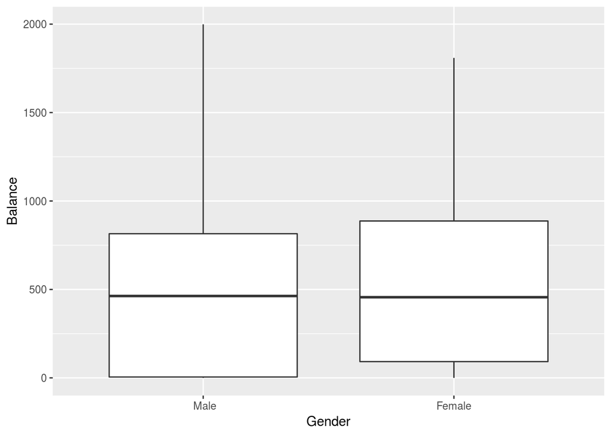

```r
ggplot(credit)+geom_boxplot(aes(x= Gender,y=Balance))
```

####Lineplot Lineplot is mostly used in Timeseries data but here we will use to show the Age of the people in dataset.

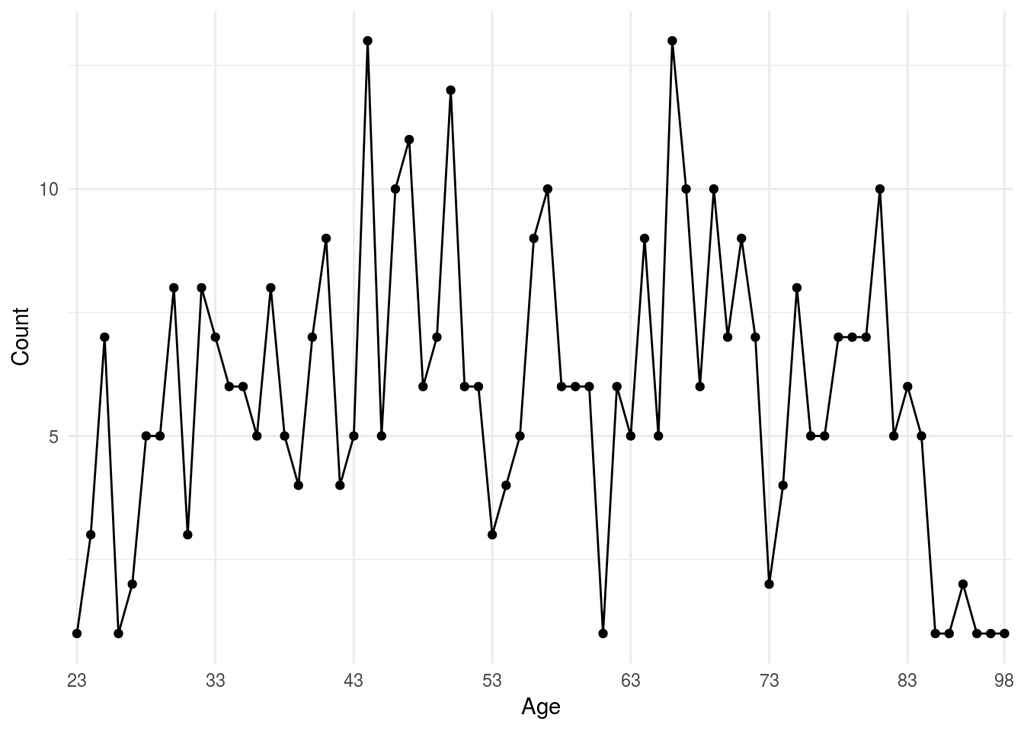

```r
age_df<-as.data.frame(table(credit$Age))
names(age_df)<-c("Age","Count")
ggplot(age_df,aes(Age,Count))+geom_line(aes(group=1))+geom_point()+scale_x_discrete(breaks=c(23,33,43,53,63,73,83,98))+theme_minimal()
```

#### Countplot

This plot shows the count of the data.

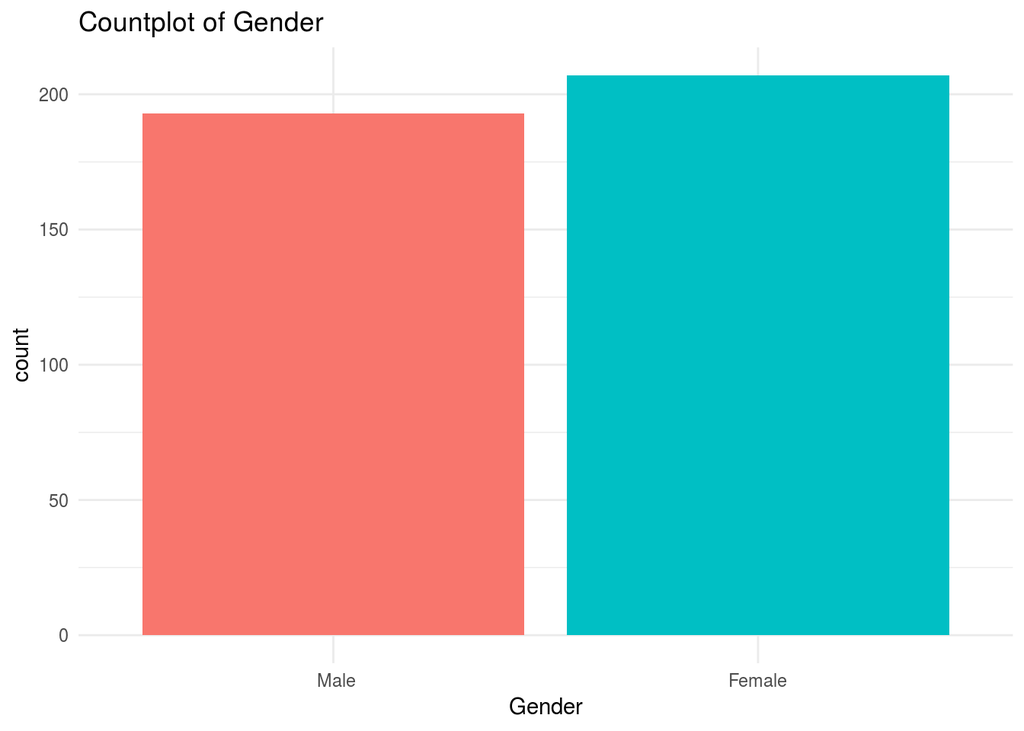

```r
ggplot(credit)+geom_bar(aes(x=Gender,fill=Gender))+labs(title="Countplot of Gender")+
  theme_minimal()+theme(legend.position = "")
```

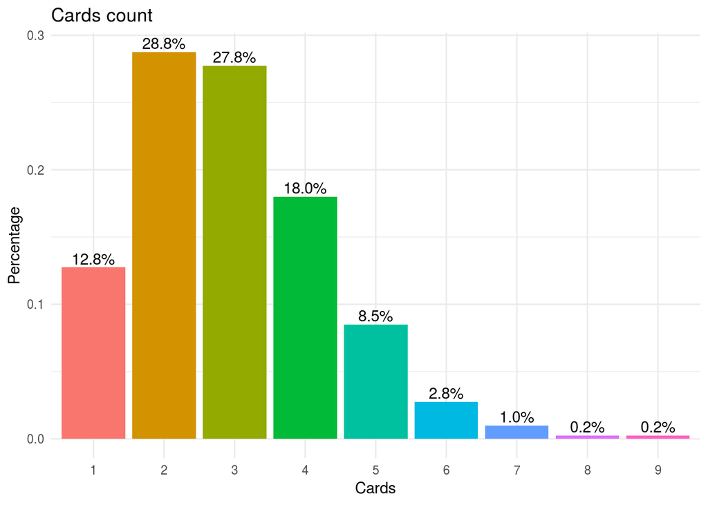

```r
credit$Cards<- as.factor(credit$Cards)
ggplot(credit,aes(x=Cards))+geom_bar(aes(y = (..count..)/sum(..count..),fill=Cards))+
  geom_text(aes(y = ((..count..)/sum(..count..)), label = scales::percent((..count..)/sum(..count..))), stat = "count", vjust = -0.25)+
  labs(title= "Cards count",y="Percentage")+
  theme_minimal()+theme(legend.position = "")
```

```r
aggregate(Income~Ethnicity,credit,mean)
```

| Ethnicity | Income |
| --- | --- |
| African American | 47.68210 |
| Asian | 44.18783 |
| Caucasian | 44.52194 |

####Multiple plots In this section we will analyse data and use multiple plots in same plots to show our insights.

```r
aggregate(Balance~Student+Gender,credit,mean)
```

| Student | Gender | Balance |
| --- | --- | --- |
| No | Male | 470.7571 |
| Yes | Male | 941.7500 |
| No | Female | 489.6667 |
| Yes | Female | 833.5417 |

*.Aggregate function Splits the data into subsets, computes summary statistics for each, and returns the result in a convenient form.

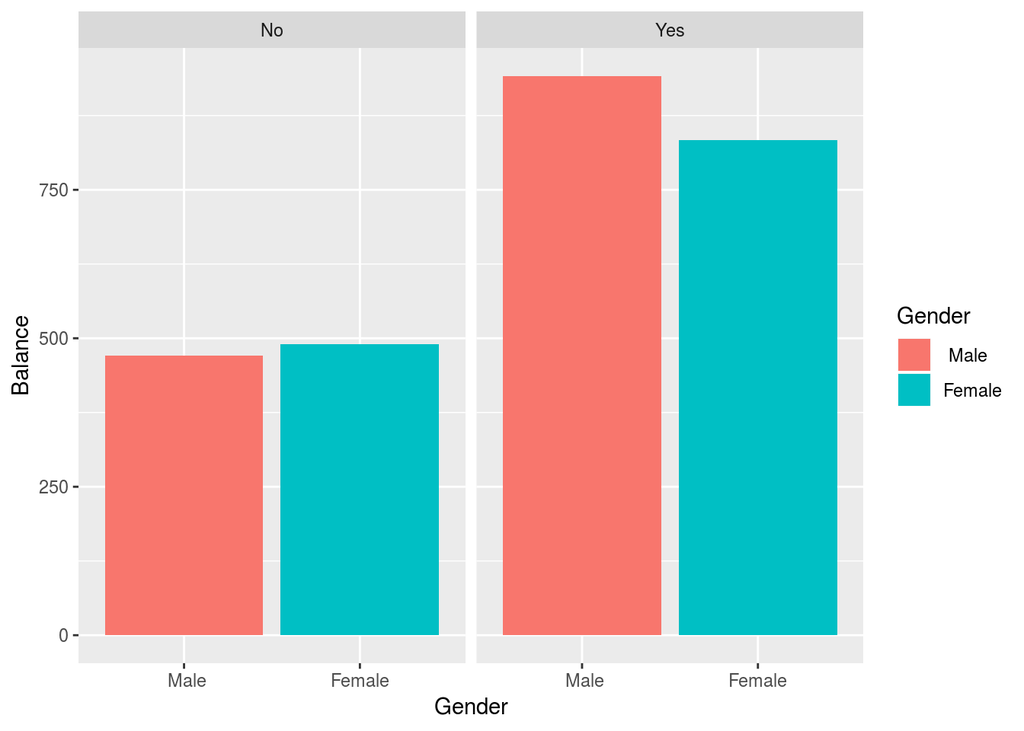

```r
ggplot(data= aggregate(Balance~Student+Gender,credit,mean),aes(x=Gender,y=Balance))+geom_col(aes(fill=Gender))+facet_grid(~Student)
```

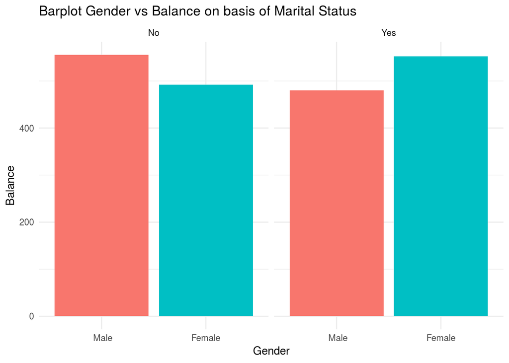

```r
ggplot(data=aggregate(Balance~Gender+Married,credit,mean),aes(Gender,Balance))+
  geom_col(aes(fill=Gender))+ggtitle("Barplot Gender vs Balance on basis of Marital Status") +facet_grid(~Married)+theme_minimal()+theme(legend.position = "")
```

This plot shows the relation Between the bank balance,Gender and their marital status.It seems married women has more cash in bank than the Married male in this dataset.

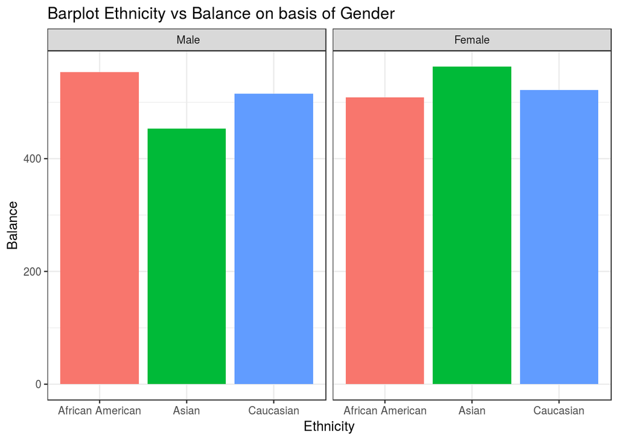

```r
ggplot(data=aggregate(Balance~Ethnicity+Gender,credit,mean),aes(Ethnicity,Balance))+
  geom_col(aes(fill=Ethnicity))+ggtitle("Barplot Ethnicity vs Balance on basis of Gender") +facet_grid(~Gender)+theme_bw()+theme(legend.position = "")
```

This was all about the data analysis.I showed basic data analysis process and you can find lots of more data insights from this dataset. Now , we will move to reporting process and lets see Report making process in R+Rstudio.